# Ejercicios 1 - Estadística descriptiva multivariante

## 2. Para la base de datos huswif del libro de Everitt(2005)[2](https://www.york.ac.uk/depts/maths/data/everitt/welcome.htm).

### a) Cargar los datos con la instrucción:

`huswif <- source("chap1huswif.dat")$value` y estudiar la base de datos con las funciones `str()` y `summary()`.

```r
> file_dir <- "C:/Users/josef/Dropbox/Documents/Personal/UOC/3er Cuatrimestre/M0.165-AM/Ejercicios/chap1huswif.dat"
>
> (huswif <- source(file_dir)$value)
```

| Hage | Hheight | Wage | Wheight | Hagefm |
| --- | --- | --- | --- | --- |
| 49 | 1809 | 43 | 1590 | 25 |
| 25 | 1841 | 28 | 1560 | 19 |
| 40 | 1659 | 30 | 1620 | 38 |
| 52 | 1779 | 57 | 1540 | 26 |
| 58 | 1616 | 52 | 1420 | 30 |
| 32 | 1695 | 27 | 1660 | 23 |
| 43 | 1730 | 52 | 1610 | 33 |
| 47 | 1740 | 43 | 1580 | 26 |
| 31 | 1685 | 23 | 1610 | 26 |
| 26 | 1735 | 25 | 1590 | 23 |

Resumen gráfico de la información en `huswif`

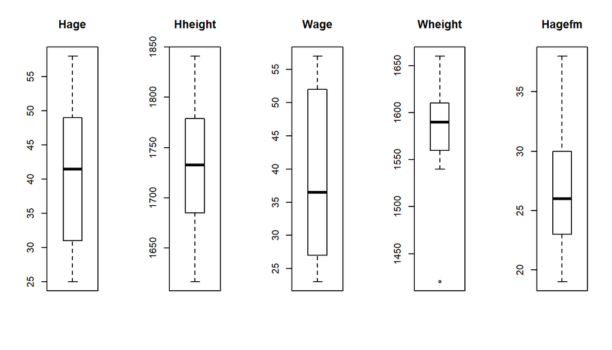

```r
> str(huswif)
```

```
'data.frame':   10 obs. of  5 variables:
 $ Hage   : num  49 25 40 52 58 32 43 47 31 26
 $ Hheight: num  1809 1841 1659 1779 1616 ...
 $ Wage   : num  43 28 30 57 52 27 52 43 23 25
 $ Wheight: num  1590 1560 1620 1540 1420 1660 1610 1580 1610 1590
 $ Hagefm : num  25 19 38 26 30 23 33 26 26 23
```

```r
> summary(huswif)
```

|  | Hage | Hheight | Wage | Wheight | Hagefm |
| --- | --- | --- | --- | --- | --- |
|  | Min. :25.00 | Min. :1616 | Min. :23.00 | Min. :1420 | Min. :19.0 |
|  | 1st Qu.:31.25 | 1st Qu.:1688 | 1st Qu.:27.25 | 1st Qu.:1565 | 1st Qu.:23.5 |
|  | Median :41.50 | Median :1732 | Median :36.50 | Median :1590 | Median :26.0 |
|  | Mean :40.30 | Mean :1729 | Mean :38.00 | Mean :1578 | Mean :26.9 |
|  | 3rd Qu.:48.50 | 3rd Qu.:1769 | 3rd Qu.:49.75 | 3rd Qu.:1610 | 3rd Qu.:29.0 |
|  | Max. :58.00 | Max. :1841 | Max. :57.00 | Max. :1660 | Max. :38.0 |

### b) Calcular estadísticos descriptivos como la media, la mediana, la varianza, etc. de todas las variables.

```r
> attach(huswif)
>
> #mean
> apply(huswif, 2, mean)
```

```
   Hage Hheight    Wage Wheight  Hagefm
   40.3  1728.9    38.0  1578.0    26.9
```

```r
> #sd
> apply(huswif, 2, sd)
```

```
     Hage   Hheight      Wage   Wheight    Hagefm
11.411982 68.607499 12.832251 64.601342  5.466057
```

```r
> #var
> apply(huswif, 2, var)
```

```
      Hage    Hheight       Wage    Wheight     Hagefm
 130.23333 4706.98889  164.66667 4173.33333   29.87778
```

```r
> #median
> apply(huswif, 2, median)
```

```
   Hage Hheight    Wage Wheight  Hagefm
   41.5  1732.5    36.5  1590.0    26.0
```

```r
> detach(huswif)
```

### c) Hallar los cinco números descriptivos de cada variable numérica. Utilizar la función fivenum().

```r
> (apply(huswif, 2, fivenum))
```

| Hage | Hheight | Wage | Wheight | Hagefm |
| --- | --- | --- | --- | --- |
| 25.0 | 1616.0 | 23.0 | 1420 | 19 |
| 31.0 | 1685.0 | 27.0 | 1560 | 23 |
| 41.5 | 1732.5 | 36.5 | 1590 | 26 |
| 49.0 | 1779.0 | 52.0 | 1610 | 30 |
| 58.0 | 1841.0 | 57.0 | 1660 | 38 |

### d) Hallar la matriz de varianzas-covarianzas y la matriz de correlaciones.

```r
> cov(huswif)
```

|  | Hage | Hheight | Wage | Wheight | Hagefm |
| --- | --- | --- | --- | --- | --- |
| Hage | 130.23333 | -192.18889 | 128.55556 | -436.0000 | 28.03333 |
| Hheight | -192.18889 | 4706.98889 | 25.88889 | 876.4444 | -229.34444 |
| Wage | 128.55556 | 25.88889 | 164.66667 | -456.6667 | 21.66667 |
| Wheight | -436.00000 | 876.44444 | -456.66667 | 4173.3333 | -8.00000 |
| Hagefm | 28.03333 | -229.34444 | 21.66667 | -8.0000 | 29.87778 |

```r
> (C <- cor(huswif))
```

|  | Hage | Hheight | Wage | Wheight | Hagefm |
| --- | --- | --- | --- | --- | --- |
| Hage | 1.0000000 | -0.2454684 | 0.8778634 | -0.5914035 | 0.4494067 |
| Hheight | -0.2454684 | 1.0000000 | 0.0294062 | 0.1977476 | -0.6115648 |
| Wage | 0.8778634 | 0.0294062 | 1.0000000 | -0.5508774 | 0.3088980 |
| Wheight | -0.5914035 | 0.1977476 | -0.5508774 | 1.0000000 | -0.0226555 |
| Hagefm | 0.4494067 | -0.6115648 | 0.3088980 | -0.0226555 | 1.0000000 |

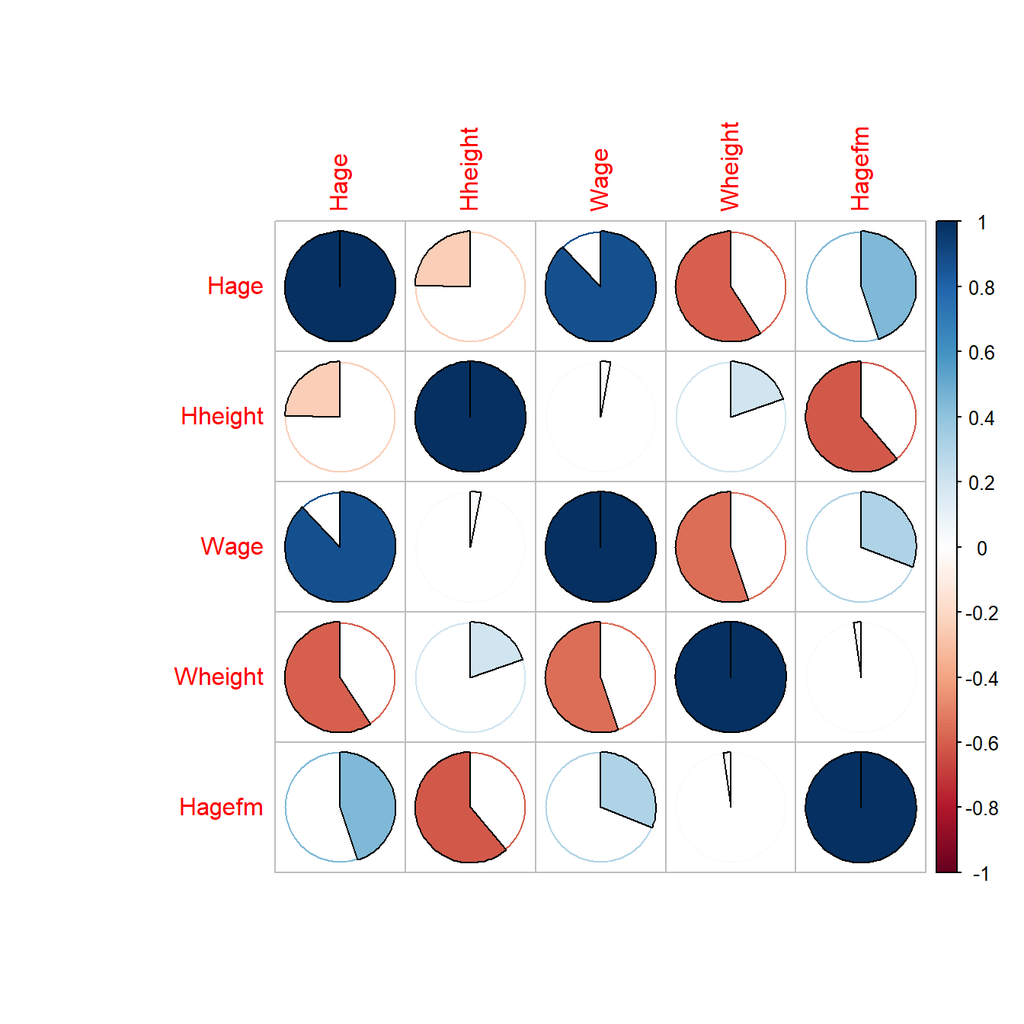

```r
> require(corrplot)
> corrplot(C, method="pie")
```

### e) Hallar las medidas globales de variabilidad: varianza total $tr(S)$, varianza media $tr(S)/p$, varianza generalizada $|S|$ y varianza efectiva $|S|^{1/p}$.

```r
> attach(huswif)
> # matriz de covarianza
> C <- cov(huswif)
> E <- eigen(C)
>
> sum(diag(C))
```

```
[1] 9205.1
```

```r
> sum(E$values)
```

```
[1] 9205.1
```

```r
> # Varianza media para todos los datos
> sum(diag(C))/length(names(huswif))
```

```
[1] 1841.02
```

```r
> # Varianza generalizada para todos los datos
> det(C)
```

```
[1] 487043516152
```

```r
> # Varianza efectiva para todos los datos
> det(C)^(1/length(names(huswif)))
```

```
[1] 217.5272
```

```r
> detach(huswif)
```

## 3. Para la base de datos airpoll del libro de Everitt(2005)

### a) Cargar los datos con la instrucción:

`airpoll <- source("chap2airpoll.dat")$value` y estudiar la base de datos con las funciones `str()` y `summary()`.

```r
> airpoll_filedir <- "C:/Users/josef/Dropbox/Documents/Personal/UOC/3er Cuatrimestre/M0.165-AM/Ejercicios/chap2airpoll.dat"
>
> airpoll <- source(airpoll_filedir)$value
```

Resumen gráfico de la información en `airpoll`

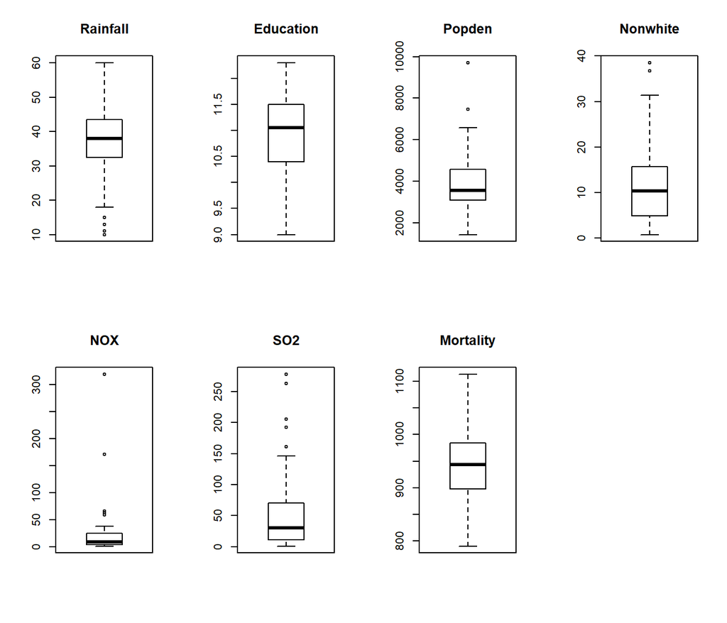

```r
> str(airpoll)
```

```
'data.frame':   60 obs. of  7 variables:
 $ Rainfall : num  36 35 44 47 43 53 43 45 36 36 ...
 $ Education: num  11.4 11 9.8 11.1 9.6 10.2 12.1 10.6 10.5 10.7 ...
 $ Popden   : num  3243 4281 4260 3125 6441 ...
 $ Nonwhite : num  8.8 3.5 0.8 27.1 24.4 38.5 3.5 5.3 8.1 6.7 ...
 $ NOX      : num  15 10 6 8 38 32 32 4 12 7 ...
 $ SO2      : num  59 39 33 24 206 72 62 4 37 20 ...
 $ Mortality: num  922 998 962 982 1071 ...
```

```r
> summary(airpoll)
```

[output not shown]

```r
> attach(airpoll)
>
> #mean
> apply(airpoll, 2, mean)
```

```
  Rainfall  Education     Popden   Nonwhite        NOX        SO2  Mortality
  37.36667   10.97333 3866.05000   11.87000   22.65000   53.76667  940.38167
```

```r
> #sd
> apply(airpoll, 2, sd)
```

```
    Rainfall    Education       Popden     Nonwhite          NOX          SO2
   9.9846775    0.8452994 1464.4792379    8.9211480   46.3332896   63.3904678
   Mortality
  62.2124258
```

```r
> #var
> apply(airpoll, 2, var)
```

```
    Rainfall    Education       Popden     Nonwhite          NOX          SO2
9.969379e+01 7.145311e-01 2.144699e+06 7.958688e+01 2.146774e+03 4.018351e+03
   Mortality
3.870386e+03
```

```r
> #median
> apply(airpoll, 2, median)
```

```
 Rainfall Education    Popden  Nonwhite       NOX       SO2 Mortality
    38.00     11.05   3567.00     10.40      9.00     30.00    943.70
```

```r
> detach(airpoll)
```

### c) Hallar los cinco números descriptivos de cada variable numérica. Utilizar la función `fivenum()`.

```r
> attach(airpoll)
> (apply(airpoll, 2, fivenum))
```

| Rainfall | Education | Popden | Nonwhite | NOX | SO2 | Mortality |
| --- | --- | --- | --- | --- | --- | --- |
| 10.0 | 9.00 | 1441.0 | 0.8 | 1.0 | 1 | 790.70 |
| 32.5 | 10.40 | 3083.5 | 4.9 | 4.0 | 11 | 897.50 |
| 38.0 | 11.05 | 3567.0 | 10.4 | 9.0 | 30 | 943.70 |
| 43.5 | 11.50 | 4565.5 | 15.7 | 24.5 | 70 | 984.15 |
| 60.0 | 12.30 | 9699.0 | 38.5 | 319.0 | 278 | 1113.00 |

```r
> detach(airpoll)
```

### d) Hallar la matriz de varianzas-covarianzas y la matriz de correlaciones.

```r
> attach(airpoll)
> cov(airpoll)
```

|  | Rainfall | Education | Popden | Nonwhite | NOX | SO2 | Mortality |
| --- | --- | --- | --- | --- | --- | --- | --- |
| Rainfall | 99.693785 | -4.1392090 | -128.6627 | 36.806102 | -225.445763 | -67.67571 | 316.43395 |
| Education | -4.139209 | 0.7145311 | -290.8885 | -1.574373 | 8.788814 | -12.55718 | -26.83677 |
| Popden | -128.662712 | -290.8884746 | 2144699.4381 | -166.510339 | 11225.577119 | 39581.65593 | 23813.64161 |
| Nonwhite | 36.806102 | -1.5743729 | -166.5103 | 79.586881 | 7.599492 | 90.08271 | 357.17436 |
| NOX | -225.445763 | 8.7888136 | 11225.5771 | 7.599492 | 2146.773729 | 1202.42542 | -223.45398 |
| SO2 | -67.675706 | -12.5571751 | 39581.6559 | 90.082712 | 1202.425424 | 4018.35141 | 1679.94480 |
| Mortality | 316.433955 | -26.8367684 | 23813.6416 | 357.174356 | -223.453983 | 1679.94480 | 3870.38593 |

```r
> (C <- cor(airpoll))
```

|  | Rainfall | Education | Popden | Nonwhite | NOX | SO2 | Mortality |
| --- | --- | --- | --- | --- | --- | --- | --- |
| Rainfall | 1.0000000 | -0.4904252 | -0.0087990 | 0.4132045 | -0.4873207 | -0.1069239 | 0.5094152 |
| Education | -0.4904252 | 1.0000000 | -0.2349810 | -0.2087739 | 0.2244019 | -0.2343459 | -0.5103199 |
| Popden | -0.0087990 | -0.2349810 | 1.0000000 | -0.0127449 | 0.1654369 | 0.4263701 | 0.2613759 |
| Nonwhite | 0.4132045 | -0.2087739 | -0.0127449 | 1.0000000 | 0.0183853 | 0.1592930 | 0.6435501 |
| NOX | -0.4873207 | 0.2244019 | 0.1654369 | 0.0183853 | 1.0000000 | 0.4093936 | -0.0775207 |
| SO2 | -0.1069239 | -0.2343459 | 0.4263701 | 0.1592930 | 0.4093936 | 1.0000000 | 0.4259846 |
| Mortality | 0.5094152 | -0.5103199 | 0.2613759 | 0.6435501 | -0.0775207 | 0.4259846 | 1.0000000 |

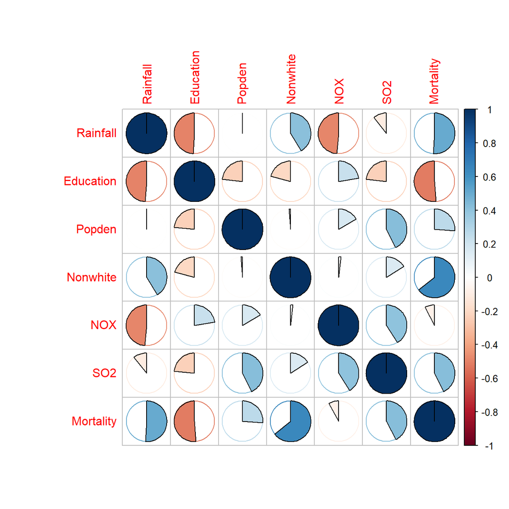

```r
> require(corrplot)
> corrplot(C, method="pie")
```

```r
> detach(airpoll)
```

### e) Hallar las medidas globales de variabilidad: varianza total $tr(S)$, varianza media $tr(S)/p$, varianza generalizada $|S|$ y varianza efectiva $|S|^{1/p}$.

```r
> attach(airpoll)
> # matriz de covarianza
> C <- cov(airpoll)
> E <- eigen(C)
>
> # varianza total para todos los datos
> sum(diag(C))
```

```
[1] 2154915
```

```r
> sum(E$values)
```

```
[1] 2154915
```

```r
> # Varianza media para todos los datos
> sum(diag(C))/length(names(airpoll))
```

```
[1] 307845
```

```r
> # Varianza generalizada para todos los datos
> det(C)
```

```
[1] 3.21166e+19
```

```r
> # Varianza efectiva para todos los datos
> det(C)^(1/length(names(airpoll)))
```

```
[1] 611.8932
```

```r
> detach(airpoll)
```

# **2. Gráficos**

## 9. Con las variables `CL` y `CW` de la base de datos `crabs` del paquete `MASS` de R:

### a) Crear el diagrama de dispersión de las dos variables y sus histogramas marginales.

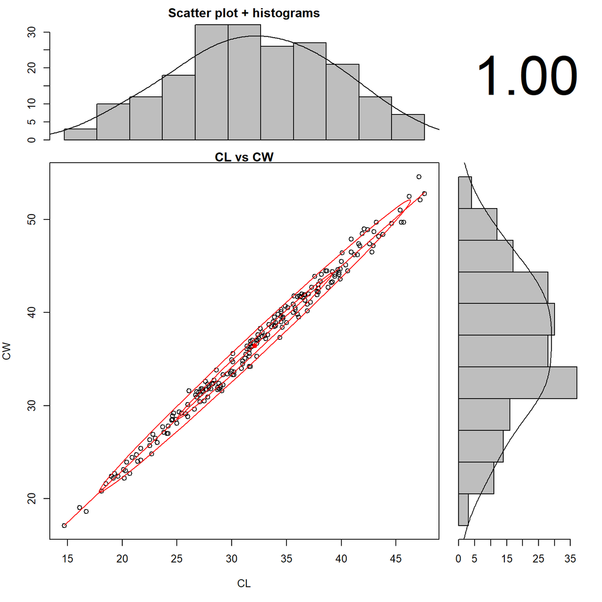

```r
> attach(crabs)
> require(psych)
> scatterHist(crabs$CL,crabs$CW, main="CL vs CW", xlab="CL", ylab="CW")
```

```r
> detach(crabs)
> # nota: no me puedo explicar de dónde sale el gráfico en
> # blanco utilizando el código de abajo
> #library(ggplot2)
> #library(ggExtra)
> #df <- data.frame(x=crabs$CL, y=crabs$CW)
> #p <- ggplot(df, aes(x, y)) + geom_point() + theme_classic()+ #labs(title="CL vs CW",x="CL", y="CW")
> #ggExtra::ggMarginal(p, type ="histogram")
```

### b) Crear el diagrama de dispersión de las dos variables y sus diagramas de caja marginales.

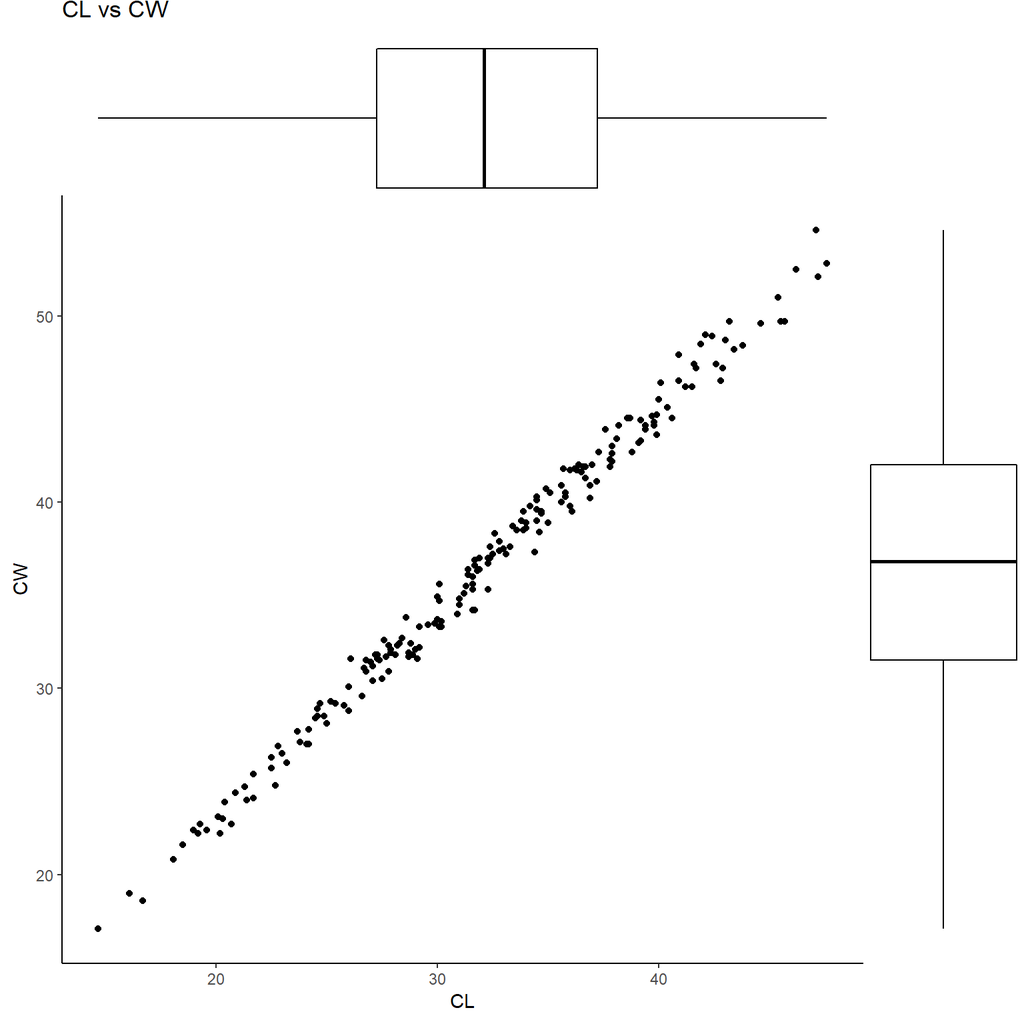

```r
> attach(crabs)
> library(ggplot2)
> library(ggExtra)
> df <- data.frame(x=crabs$CL, y=crabs$CW)
> p <- ggplot(df, aes(x, y)) + geom_point() + theme_classic() + labs(title="CL vs CW",x="CL", y="CW")
> ggExtra::ggMarginal(p, type = "boxplot")
```

```r
> detach(crabs)
> # Nota: no me puedo explicar de dónde sale el gráfico
> # en blanco utilizando el código de abajo
```

[output not shown]

## 10. Con la base de datos crabs del paquete MASS de R, realizar los siguientes diagramas de caja múltiples:

### a) Para comparar las variables según especie.

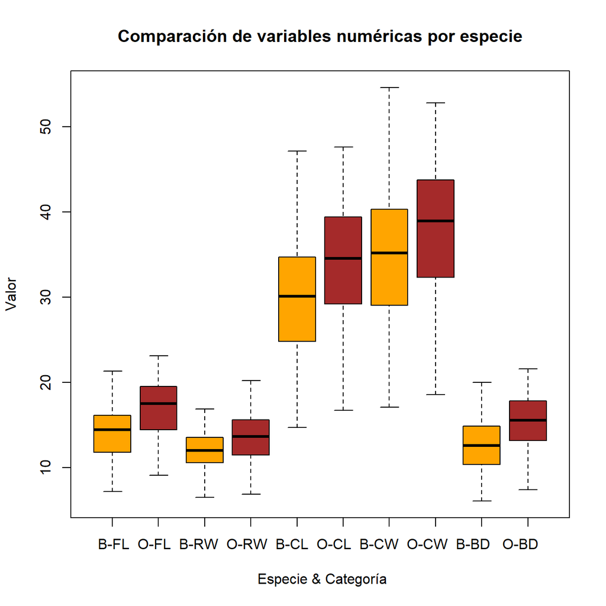

```r
> attach(crabs)
>
> B <- crabs_num[crabs$sp=="B",]
> O <- crabs_num[crabs$sp=="O",]
>
> boxplot(B$FL, O$FL, B$RW, O$RW, B$CL, O$CL, B$CW, O$CW, B$BD, O$BD, main="Comparación de variables numéricas por especie", xlab="B-FL  O-FL  B-RW  O-RW  B-CL  O-CL  B-CW  O-CW  B-BD   O-BD \n\n Especie & Categoría", ylab="Valor", col = c("orange","brown"))
```

```r
> detach(crabs)
```

### b) Para comparar las variables según sexo.

[figure not shown]

```r
> attach(crabs)
> f <- crabs_num[crabs$sex=="F",]
> m <- crabs_num[crabs$sex=="M",]
>
> boxplot(f$FL, m$FL, f$RW, m$RW, f$CL, m$CL, f$CW, m$CW, f$BD, m$BD, main="Comparación de variables numéricas por especie", xlab="F-FL   M-FL   F-RW   M-RW   F-CL   M-CL   F-CW   M-CW   F-BD    M-BD \n\n Especie & Categoría", ylab="Valor", col = c("red","blue"))
```

```r
> detach(crabs)
```

### c) Para comparar las variables según especie y sexo.

[figure not shown]

```r
> attach(crabs)
> BF_nnum <- subset(crabs_num, crabs$sex=="F" & crabs$sp=="B")
>
>
> BM_nnum <- subset(crabs_num, crabs$sex=="M" & crabs$sp=="B")
>
>
> OF_nnum <- subset(crabs_num, crabs$sex=="F" & crabs$sp=="O")
>
>
> OM_nnum <- subset(crabs_num, crabs$sex=="M" & crabs$sp=="O")
>
> BF <- BF_nnum[3:8,]
> BM <- BM_nnum[3:8,]
> OF <- OF_nnum[3:8,]
> OM <- OF_nnum[3:8,]
>
> boxplot(BF$FL, BM$FL, OF$FL, OF$FL, BF$RW, BM$RW, OF$RW, OF$RW, BF$CL, BM$CL, OF$CL, OF$CL, BF$CW, BM$CW, OF$CW, OF$CW,BF$BD, BM$BD, OF$BD, OF$BD, main="Comparación de variables numéricas por especie y sexo", xlab="\n\n Especie, Sexo & Categoría", ylab="Valor", col = c("blue", "red", "purple", "yellow", "pink", "green", "orange", "mediumpurple", "lightblue", "brown", "cyan", "magenta", "grey","maroon", "violet","purple", "gold","snow", "bisque", "deepskyblue"))
>
> legend(0.1,33,lty=1,c("BF$FL", "BM$FL", "OF$FL", "OF$FL", "BF$RW", "BM$RW", "OF$RW", "OF$RW", "BF$CL", "BM$CL", "OF$CL", "OF$CL", "BF$CW", "BM$CW", "OF$CW", "OF$CW", "BF$BD", "BM$BD", "OF$BD", "OF$BD"),col=c("blue", "red", "purple", "yellow", "pink", "green", "orange", "mediumpurple", "lightblue", "brown", "cyan", "magenta", "grey","maroon", "violet","purple", "gold","snow", "bisque", "deepskyblue"),title="Leyenda",cex=1.5)
```

```r
> detach(crabs)
```